# 8.2 Spatial autocorrelation

**Spatial autocorrelation** describes the association between values recorded at nearby locations. Positive spatial autocorrelation means that nearby values are more similar than expected, and negative spatial autocorrelation means that they are more different. Either can be a pattern of interest, and spatial autocorrelation can violate the independence assumed by a statistical analysis. The statistic depends on how neighboring locations and their weights are defined.

In this optional lesson, we will measure spatial autocorrelation in median income across census tracts of the District of Columbia and in a raster of canopy cover. We will define neighbors and weights, calculate and test Moran’s I, map local clusters, examine changes across distance bands, and connect those results with sampling design.

In completing this lesson, you will learn how to:

- Define the neighbors of each polygon with `st_contiguity()` and weight them with `st_weights()`
- Calculate the spatial lag of a variable with `st_lag()`, and describe what Moran’s I measures
- Test Moran’s I against chance with `global_moran_test()` and `global_moran_perm()`
- Map the clusters of high and low values with `local_moran()`
- Measure how autocorrelation changes with distance using `st_dist_band()` and `pmap_dbl()`
- Calculate Moran’s I for a raster with `autocor()`, and state how the spacing of samples changes their autocorrelation

**Important!** Before starting this tutorial, be sure that you have completed all preliminary and previous lessons!

## Data for this lesson

**`dc_census.geojson`**: A polygon shapefile of census tracts in the District of Columbia. The data are in a projected coordinate system (datum = WGS84, projection is UTM, Zone 18N) with the EPSG code 32618.

The data include the following fields:

- `GEOID`, character: The **primary key** for each census tract.
- `STATEFP`, character: A **foreign key** to the US state in the `states` data.
- `ALAND`, numeric: The area covered by land in each census tract, in square meters.
- `AWATER`, numeric: The area covered by water in each census tract, in square meters.
- `INCOME`, numeric: The median income of each census tract.
- `POPULATION`, numeric: The total population of each census tract.

**`dc_stack.tif`**: This is a geotiff raster stack of land cover files from the the Multi-Resolution Land Characteristics Consortium (MRLC). The resolution of the stack is 30 by 30 meters and the CRS of the object is EPSG 5070. Layers include canopy (percent canopy cover, 0 to 94), imp (percent impervious surface, 0 to 100), nlcd (classified land cover of each cell) and land (1 in every cell that holds data). All four layers share one set of missing cells, so a cell that is NA in land is NA in the other three as well.

## Set up your session

Begin with a clean session:

1. Ensure that your **Global Environment** is empty.
2. In the *History* tab of your **workspace pane**, ensure that your **session history** is empty.

Next:

1. Create a script file.
2. Save your script file as `scripts/spatial_autocorrelation.R`.
3. Add metadata as a comment on the top of the file.
4. Create a **code section** called “`setup`” after the metadata.
5. Attach *sf*, *sfdep*, *tidyterra*, *tmap*, and the packages that comprise the **core tidyverse**, then load the module 3 source script.

Your script should look something like:

```r
# My code for the spatial autocorrelation tutorial

# setup --------------------------------------------------------

library(sf)
library(sfdep)
library(tidyterra)
library(tmap)
library(tidyverse)

# Load the source script:

source("scripts/source_script_module_3.R")

# Draw interactive maps:

tmap_mode("view")
```

*sfdep* is new to the course. It supplies the functions of the *spdep* package, which is the standard package for spatial dependence in R, in a form that returns vectors and list columns, so that the neighbors and weights of a polygon are stored beside its fields in a simple features object and the functions run inside `mutate()`.

Next, please create a code section called “`read and pre-process data`”. Let’s read the census tracts, keeping the tract identifier, the median income, and the population:

```r
census <-
  st_read(
    "data/raw/shapefiles/dc_census.geojson",
    quiet = TRUE
  ) %>%
  clean_names() %>%
  select(
    geoid,
    income,
    population
  ) %>%
  st_transform(32618)
```

Let’s check the fields for missing values:

```r
census %>%
  st_drop_geometry() %>%
  summarize(
    tracts = n(),
    missing_income = sum(is.na(income)),
    zero_population = sum(population == 0)
  )
```

```
  tracts missing_income zero_population
1    179              3               1
```

Three tracts have no median income, and one of those has no residents. A tract with no value cannot be compared with its neighbors, so let’s remove them:

```r
tracts <-
  census %>%
  filter(
    !is.na(income)
  )
```

Please read the canopy layer of the District raster stack (see *6.1 Introduction to rasters with terra*):

```r
canopy <-
  terra::rast("data/raw/rasters/dc_stack.tif") %>%
  select(canopy)
```

## Moran’s I

Correlation describes the relationship between two variables measured on the same observations. Spatial autocorrelation describes the relationship between one variable and *itself*, measured at neighboring locations. Calculating it requires decisions, and the statistic follows from them:

1. Neighbors: for each location, which other locations count as nearby.
2. Weights: how much each neighbor counts.
3. The lag: the weighted mean of a variable across a location’s neighbors, which is what we compare the location’s own value with.

With row-standardized weights, **Moran’s I** is the slope of the line through a plot of the spatial lag of a standardized variable against that standardized variable, which we will draw below. It is positive when locations with high values have neighbors with high values, close to zero when nearby values show little association, and negative when high values occur beside low values. Moran’s I is not bounded by -1 and 1 as a correlation coefficient is, although its values usually fall in that range.

### Contiguous neighbors

For polygons, the usual definition of a neighbor is **contiguity**: two tracts are neighbors when they share a boundary. `st_contiguity()` returns, for each polygon, the row numbers of the polygons that touch it. Let’s add the neighbors as a column:

```r
tracts %>%
  mutate(
    neighbors = st_contiguity(geometry)
  ) %>%
  st_drop_geometry() %>%
  slice_head(n = 3)
```

```
        geoid income population                     neighbors
1 11001010900  32143       3470             75, 142, 147, 168
2 11001010400  40025       4368 69, 74, 75, 81, 160, 168, 170
3 11001009903  55665       1319               4, 10, 136, 152
```

The `neighbors` column is a list column: each row contains a vector of row numbers rather than a single value. Let’s extract the first:

```r
tracts %>%
  mutate(
    neighbors = st_contiguity(geometry)
  ) %>%
  pull(neighbors) %>%
  pluck(1)
```

```
[1]  75 142 147 168
```

The first tract touches four others. By default, `st_contiguity()` counts two polygons as neighbors when they share any point of their boundaries, including a single corner, which its documentation calls the queen rule after the moves of the chess piece. Let’s count the neighbors of each tract:

```r
tracts %>%
  mutate(
    neighbors = st_contiguity(geometry),
    n_neighbors = lengths(neighbors)
  ) %>%
  st_drop_geometry() %>%
  count(n_neighbors)
```

```
   n_neighbors  n
1            2  5
2            3 12
3            4 25
4            5 46
5            6 29
6            7 32
7            8 17
8            9  7
9           10  1
10          12  1
11          13  1
```

Tracts at the edge of the city and along the river have few neighbors, and tracts in the interior have several.

### Spatial weights

Each neighbor receives a **spatial weight**, and the weights of a location’s neighbors are what its lag is calculated from. `st_weights()` returns them from the neighbor list. Its default, which the *spdep* documentation calls row-standardized weights, gives each neighbor an equal share of one:

```r
tracts %>%
  mutate(
    neighbors = st_contiguity(geometry),
    weights = st_weights(neighbors)
  ) %>%
  pull(weights) %>%
  pluck(1)
```

```
[1] 0.25 0.25 0.25 0.25
```

The first tract has four neighbors, so each carries a weight of one quarter, and the weights sum to one. With these weights, the lag of a location is the plain mean of its neighbors’ values.

### Spatial lag

`st_lag()` calculates the lag from the variable, the neighbors, and the weights. The neighbors and the weights do not depend on the variable, so let’s build the columns in one statement and assign the result, which every later section of the lesson uses:

```r
tract_neighbors <-
  tracts %>%
  mutate(
    neighbors = st_contiguity(geometry),
    weights = st_weights(neighbors),
    income_standardized =
      (income - mean(income)) / sd(income),
    income_lag =
      st_lag(
        income,
        neighbors,
        weights
      ),
    standardized_lag =
      st_lag(
        income_standardized,
        neighbors,
        weights
      )
  )

tract_neighbors %>%
  st_drop_geometry() %>%
  select(
    geoid,
    income,
    income_lag
  ) %>%
  slice_head(n = 5)
```

```
        geoid income income_lag
1 11001010900  32143   39180.25
2 11001010400  40025   36078.57
3 11001009903  55665   35647.00
4 11001009904  37083   39537.00
5 11001000902 184583  171042.00
```

Each row now contains the tract’s median income, the mean median income of its contiguous neighbors, and standardized versions for the Moran scatterplot. Standardization subtracts the citywide mean and divides by the standard deviation, so zero represents the mean. Let’s draw the standardized pairs:

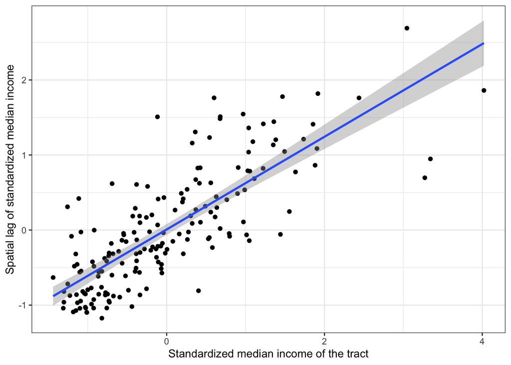

```r
tract_neighbors %>%
  ggplot() +
  aes(
    x = income_standardized,
    y = standardized_lag
  ) +

  # Add geometries:

  geom_point() +
  geom_smooth(
    method = "lm",
    formula = y ~ x
  ) +

  # Add labels:

  labs(
    x = "Standardized median income of the tract",
    y = "Spatial lag of standardized median income"
  ) +

  # Modify the theme:

  theme_bw()
```

A tract with a high median income has neighbors with high median incomes. This plot is the **Moran scatterplot**, and the slope of the line through it is Moran’s I.

Check your understanding

A polygon has five contiguous neighbors, and `st_weights()` is called with its defaults. What weight does each neighbor receive?

0.2, so that the weights sum to one 1, so that each neighbor counts fully 5, the number of neighbors A weight proportional to the length of the shared boundary

True or false: The spatial lag of a tract is the mean of the values of its neighbors, when the weights are row-standardized.

## Global Moran’s I

`global_moran()` calculates the statistic from the same columns:

```r
tract_neighbors %>%
  st_drop_geometry() %>%
  summarize(
    moran =
      global_moran(
        income,
        neighbors,
        weights
      ) %>%
      pluck("I")
  )
```

```
      moran
1 0.6175441
```

Median income in the District is strongly autocorrelated: a tract with a high income has neighbors with high incomes, and a tract with a low income has neighbors with low incomes. The statistic is called global because it describes the whole map with one number.

### Tests against spatial randomness

A statistic needs a comparison. What should Moran’s I look like if the incomes were assigned to the tracts at random? Most tracts would have a mix of richer and poorer neighbors, so the statistic should be close to zero. Let’s shuffle the income column once and calculate the statistic again:

```r
set.seed(2026)

tract_neighbors %>%
  mutate(
    income_shuffled = sample(income)
  ) %>%
  st_drop_geometry() %>%
  summarize(
    moran =
      global_moran(
        income_shuffled,
        neighbors,
        weights
      ) %>%
      pluck("I")
  )
```

```
        moran
1 -0.04801504
```

The same values on a shuffled map have a Moran’s I close to zero. `sample()` with one argument returns its argument in a random order, so the shuffled column contains the same incomes attached to different tracts.

`global_moran_test()` makes the same comparison analytically. It calculates the expected value and variance of Moran’s I under randomization, and reports the distance between the observed value and that expectation in standard deviations:

```r
global_moran_test(
  tract_neighbors$income,
  tract_neighbors$neighbors,
  tract_neighbors$weights
)
```

```
    Moran I test under randomisation

data:  x
weights: listw

Moran I statistic standard deviate = 13.834, p-value < 2.2e-16
alternative hypothesis: greater
sample estimates:
Moran I statistic       Expectation          Variance
      0.617544064      -0.005714286       0.002029838
```

The expected value under randomization is close to zero, the variance is small, and the observed value is many standard deviations above it. Under a random arrangement of the incomes, a statistic at least this large would be extremely unlikely.

`global_moran_perm()` repeatedly shuffles the values among tracts and compares the resulting statistics with the observed statistic:

```r
set.seed(2026)

global_moran_perm(
  tract_neighbors$income,
  tract_neighbors$neighbors,
  tract_neighbors$weights,
  nsim = 999
)
```

```
    Monte-Carlo simulation of Moran I

data:  x
weights: listw
number of simulations + 1: 1000

statistic = 0.61754, observed rank = 1000, p-value < 2.2e-16
alternative hypothesis: two.sided
```

The observed value has rank 1000 among the 999 shuffled results and the observed result. The permutation test requires fewer distributional assumptions than the analytical test, and I prefer it when the number of polygons makes the simulation practical.

Report the neighbor definition with the statistic!

Moran’s I is a property of the variable *and* of the neighbor list. Contiguity with the queen rule, contiguity with the rook rule, the four nearest neighbors, and every polygon within two kilometers are different neighbor lists, and each returns a different value of I from the same data.

There is no universally correct definition. Choose the one that matches how the process spreads, state it beside the statistic, and check that the conclusion survives a second reasonable definition before reporting it.

Now you!

Calculate Moran’s I for the population of the tracts, using the neighbors and weights already in `tract_neighbors`, and test it with `global_moran_perm()`.

*Hint: The columns `neighbors` and `weights` do not depend on the variable, so the same columns serve any field of the object.*

Click here to see my answer

```r
set.seed(2026)

global_moran_perm(
  tract_neighbors$population,
  tract_neighbors$neighbors,
  tract_neighbors$weights,
  nsim = 999
)
```

```
    Monte-Carlo simulation of Moran I

data:  x
weights: listw
number of simulations + 1: 1000

statistic = 0.15988, observed rank = 1000, p-value < 2.2e-16
alternative hypothesis: two.sided
```

Population is autocorrelated across the tracts as well, and less strongly than income. The neighbors and weights were calculated once and serve both variables, which is the reason to store them as columns of the object.

## Local Moran’s I

A global statistic establishes that clusters exist without locating them. **Local Moran’s I** is the statistic calculated for each polygon on its own, from the polygon’s value and the values of its neighbors, with a label for whether the polygon’s value and its neighbors’ mean fall above or below their means.

`local_moran()` returns a data frame with one row per polygon, and `nsim =` sets the number of shuffles used to test each one. Let’s calculate it as a column and look at what the column contains:

```r
set.seed(2026)

tract_neighbors %>%
  mutate(
    local_moran =
      local_moran(
        income,
        neighbors,
        weights,
        nsim = 999
      )
  ) %>%
  pull(local_moran) %>%
  names()
```

```
 [1] "ii"           "eii"          "var_ii"       "z_ii"         "p_ii"
 [6] "p_ii_sim"     "p_folded_sim" "skewness"     "kurtosis"     "mean"
[11] "median"       "pysal"
```

The column is a data frame inside a data frame. `unnest()` from *tidyr* expands it into ordinary columns. Let’s calculate the column again, expand it, and assign the result:

```r
set.seed(2026)

local <-
  tract_neighbors %>%
  mutate(
    local_moran =
      local_moran(
        income,
        neighbors,
        weights,
        nsim = 999
      )
  ) %>%
  unnest(local_moran) %>%
  mutate(
    p_adjusted = p.adjust(p_ii_sim, method = "BH")
  )

local %>%
  st_drop_geometry() %>%
  select(
    geoid,
    income,
    ii,
    p_ii_sim,
    p_adjusted,
    mean
  ) %>%
  slice_head(n = 5)
```

```
# A tibble: 5 × 6
  geoid       income    ii p_ii_sim p_adjusted mean
  <chr>        <dbl> <dbl>    <dbl>      <dbl> <fct>
1 11001010900  32143 0.741    0.078     0.205  Low-Low
2 11001010400  40025 0.642    0.008     0.0503 Low-Low
3 11001009903  55665 0.294    0.046     0.135  Low-Low
4 11001009904  37083 0.633    0.026     0.0915 Low-Low
5 11001000902 184583 8.24     0.002     0.0469 High-High
```

We will use the following columns:

- `ii` is the local statistic for the tract, which is positive when the tract and its neighbors are on the same side of the mean.
- `p_ii_sim` is the two-sided p-value from the shuffles.
- `p_adjusted` is the p-value after `p.adjust()` applies the Benjamini-Hochberg correction. The correction limits the expected share of false discoveries among the tracts we select.
- `mean` labels the tract as `High-High`, `Low-Low`, `High-Low`, or `Low-High`, from whether its own income falls above or below the citywide mean and whether the mean income of its neighbors falls above or below the average of those neighbor means. The first half of the label is always the tract’s own value.

Let’s keep the label for the tracts whose local statistic is unlikely under chance and set the rest to a single category:

```r
clusters <-
  local %>%
  mutate(
    cluster =
      if_else(
        p_adjusted < 0.05,
        as.character(mean),
        "Not significant"
      )
  )

clusters %>%
  st_drop_geometry() %>%
  count(cluster)
```

```
# A tibble: 3 × 2
  cluster             n
  <chr>           <int>
1 High-High           6
2 Low-Low             9
3 Not significant   161
```

Most tracts are not part of a cluster that the adjusted tests can distinguish from chance. The rest divide into a block of high-income tracts surrounded by high-income tracts and a block of low-income tracts surrounded by low-income tracts. `tm_scale_categorical()` is the scale for a categorical fill, in the position that `tm_scale_intervals()` took for a numeric one (see *5.5 Cartography II: Projection, context, and labels*), and a named vector in `values =` assigns a color to each category by name. Let’s map them:

```r
clusters %>%
  tm_shape() +
  tm_polygons(
    fill = "cluster",
    fill.scale =
      tm_scale_categorical(
        values =
          c(
            "High-High" = "firebrick",
            "Low-Low" = "steelblue",
            "High-Low" = "salmon",
            "Low-High" = "lightblue",
            "Not significant" = "grey85"
          )
      ),
    fill.legend = tm_legend(title = "Local Moran's I")
  )
```

[interactive chart not shown]

The high-income cluster occupies the northwest of the city and the low-income cluster the southeast, across the Anacostia River. We summarized the whole map with one number; the local statistic is a value for each tract, and this map is what those values show.

A local test is many tests

`local_moran()` runs a separate test on every polygon, so a map of 176 tracts is drawn from 176 p-values, and some of them are small by chance. At a threshold of 0.05, approximately one tract in 20 would pass by chance when no cluster exists.

The Benjamini-Hochberg correction reduces that problem, but it does not turn a local cluster into an explanation. Read the blocks of adjacent tracts rather than isolated results, and describe the neighbor definition and correction with the map.

Check your understanding

A tract is labeled `High-Low` by `local_moran()`. What does the label describe?

The tract's value is above the mean and its neighbors' mean is below it The tract's value is below the mean and its neighbors' mean is above it The tract's value fell from high to low The tract has a high value and a low p-value

True or false: A significant global Moran’s I means that every tract is part of a local cluster.

## Spatial correlograms

Contiguity measures similarity among tracts that touch. We may instead need to know how similarity changes with distance: do tracts two kilometers apart still resemble one another, and tracts ten kilometers apart? A **correlogram** is a set of Moran’s I values, one for each of a sequence of distance bands. Within each band, the neighbors of a location are the locations at that range of distances from it.

We will represent each tract with its centroid when defining distance bands. `st_centroid()` returns those points (see *5.1 Focus on points: Occurrence records and sampling*):

```r
centroids <-
  tracts %>%
  st_centroid()
```

`st_centroid()` returns the warning that it *assumes attributes are constant over geometries*, which is the warning *5.3 Focus on polygons: Boundaries, attributes, and areas* explained: the income of a tract is carried to a point that stands for the whole tract, which is what we intend here.

`st_dist_band()` returns the neighbors between a lower and an upper distance from each point. Let’s define the bands:

```r
bands <-
  tibble(
    lower =
      seq(
        from = 0,
        to = 8000,
        by = 2000
      ),
    upper = lower + 2000
  )
```

```
# A tibble: 5 × 2
  lower upper
  <dbl> <dbl>
1     0  2000
2  2000  4000
3  4000  6000
4  6000  8000
5  8000 10000
```

`pmap_dbl()` iterates over the rows of a data frame, calling its function with one argument per column and returning a numeric vector (see *4.4 Iteration with purrr*). The formals take the column names. For each band, the function builds the neighbor list, weights it, and returns Moran’s I:

```r
correlogram <-
  bands %>%
  mutate(
    moran =
      pmap_dbl(
        bands,
        \(lower, upper) {

          # Neighbors within the band:

          band_neighbors <-
            st_dist_band(
              centroids$geometry,
              lower = lower,
              upper = upper
            )

          band_weights <-
            st_weights(
              band_neighbors,
              allow_zero = TRUE
            )

          # Moran's I for the band:

          global_moran(
            centroids$income,
            band_neighbors,
            band_weights,
            zero.policy = TRUE
          ) %>%
            pluck("I")
        }
      )
  )
```

```
# A tibble: 5 × 3
  lower upper   moran
  <dbl> <dbl>   <dbl>
1     0  2000  0.519
2  2000  4000  0.244
3  4000  6000  0.0572
4  6000  8000  0.0214
5  8000 10000 -0.0171
```

`allow_zero = TRUE` and `zero.policy = TRUE` are needed because a tract near the edge of the city can have no neighbor in a given band. Without the first, `st_weights()` stops with an error when it finds an empty neighbor set. Without the second, the lag of those tracts is `NA`, and so is the statistic.

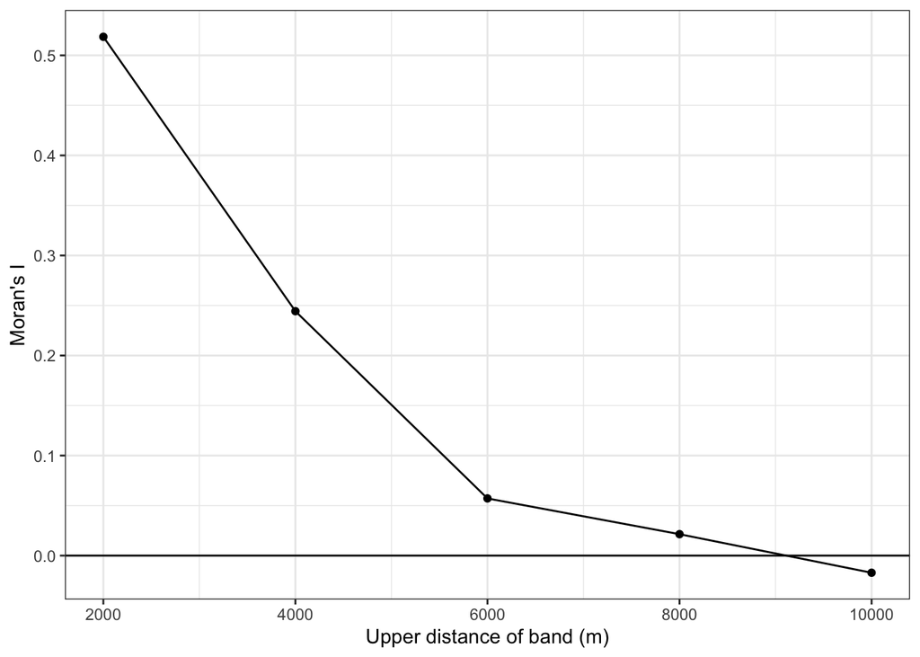

```r
correlogram %>%
  ggplot() +
  aes(
    x = upper,
    y = moran
  ) +

  # Add geometries:

  geom_hline(yintercept = 0) +
  geom_line() +
  geom_point() +

  # Add labels:

  labs(
    x = "Upper distance of band (m)",
    y = "Moran's I"
  ) +

  # Modify the theme:

  theme_bw()
```

The observed autocorrelation in income is strongest in the shortest distance band and decreases as distance increases. In this descriptive correlogram, values approach zero by approximately 6 km. The **range** is the distance over which positive spatial autocorrelation remains evident, although a formal estimate should also include uncertainty around each value.

Now you!

Repeat the correlogram for the population of the tracts.

*Hint: Only the variable inside `global_moran()` changes.*

Click here to see my answer

```r
bands %>%
  mutate(
    moran =
      pmap_dbl(
        bands,
        \(lower, upper) {

          # Neighbors within the band:

          band_neighbors <-
            st_dist_band(
              centroids$geometry,
              lower = lower,
              upper = upper
            )

          band_weights <-
            st_weights(
              band_neighbors,
              allow_zero = TRUE
            )

          # Moran's I for the band:

          global_moran(
            centroids$population,
            band_neighbors,
            band_weights,
            zero.policy = TRUE
          ) %>%
            pluck("I")
        }
      )
  )
```

```
# A tibble: 5 × 3
  lower upper    moran
  <dbl> <dbl>    <dbl>
1     0  2000  0.176
2  2000  4000  0.122
3  4000  6000  0.0581
4  6000  8000 -0.00722
5  8000 10000 -0.107
```

Population has a smaller Moran’s I than income in the shortest distance band. The remaining differences are small, so this correlogram does not support a precise difference in range.

## Raster autocorrelation

For rasters, `autocor()` calculates Moran’s I directly from the grid. Its default weight matrix uses the surrounding cells in a 3 by 3 neighborhood, excluding the focal cell:

```r
canopy %>%
  terra::autocor(standardize = TRUE)
```

```
   canopy
0.8502419
```

Canopy cover at 30 meters is strongly autocorrelated, because percent cover changes gradually across the city rather than from one cell to the next. Notice what happens when we coarsen the grid (see *6.3 Changing the grid: Resolution, extent and projection*):

```r
canopy %>%
  terra::aggregate(
    fact = 10,
    fun = "mean",
    na.rm = TRUE
  ) %>%
  terra::autocor(standardize = TRUE)
```

```
  canopy
0.722076
```

For these data, the statistic is lower at 300 meters. Aggregation changes both the cell values and the distances among neighboring cells, so Moran’s I depends on the raster’s resolution as well as on the landscape.

`global = FALSE` returns the local statistic as a raster rather than a layer-wide summary. A cell with no canopy value returns `NA`, so the result covers the same cells as `canopy`:

```r
canopy_local <-
  canopy %>%
  terra::autocor(global = FALSE)
```

```
class       : SpatRaster
size        : 716, 621, 1  (nrow, ncol, nlyr)
resolution  : 30, 30  (x, y)
extent      : 1610775, 1629405, 1914705, 1936185  (xmin, xmax, ymin, ymax)
coord. ref. : NAD83 / Conus Albers (EPSG:5070)
source(s)   : memory
varname     : dc_stack
name        :    canopy
min value   : -1.676612
max value   :  7.317548
```

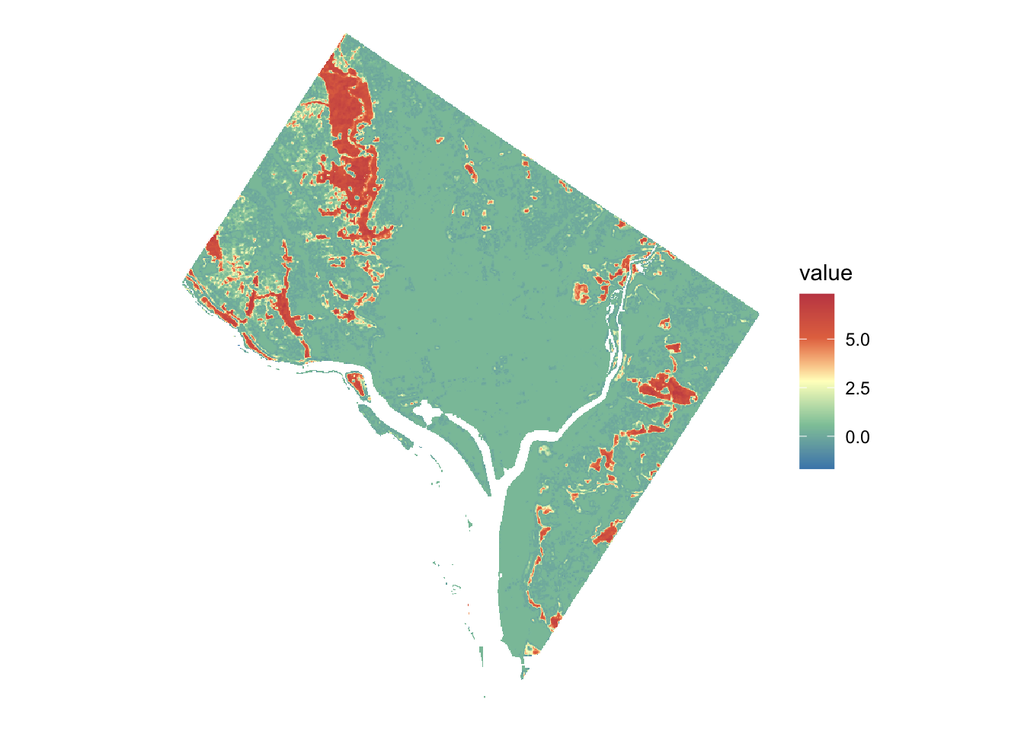

```r
ggplot() +

  # Add the raster layer:

  geom_spatraster(data = canopy_local) +

  # Define the scale:

  scale_fill_whitebox_c(palette = "muted") +

  # Define the theme:

  theme_void()
```

## Spatial autocorrelation and sampling design

Samples taken from the same cluster carry much of the same information. A sampling design that ignores positive autocorrelation collects many samples and less information than their number suggests, and a method that treats those samples as independent understates their standard errors.

Let’s draw a random sample from the canopy raster (see *7.3 Raster operations*). `st_knn()` identifies the `k` nearest points for each sample location. We will use the four nearest points as neighbors and calculate Moran’s I for the sampled values:

```r
set.seed(2026)

random_sample <-
  canopy %>%
  terra::spatSample(
    size = 500,
    method = "random",
    as.points = TRUE,
    na.rm = TRUE
  ) %>%
  st_as_sf()

random_neighbors <-
  st_knn(
    random_sample$geometry,
    k = 4
  )

random_weights <-
  st_weights(random_neighbors)

global_moran_test(
  random_sample$canopy,
  random_neighbors,
  random_weights
)
```

```
    Moran I test under randomisation

data:  x
weights: listw

Moran I statistic standard deviate = 17.1, p-value < 2.2e-16
alternative hypothesis: greater
sample estimates:
Moran I statistic       Expectation          Variance
     0.5040275254     -0.0020040080      0.0008756728
```

The canopy values at nearby random samples are strongly autocorrelated, so the sample provides less independent information than 500 independent measurements would. Let’s draw a regular sample for comparison:

```r
regular_sample <-
  canopy %>%
  terra::spatSample(
    size = 500,
    method = "regular",
    as.points = TRUE
  ) %>%
  st_as_sf() %>%
  filter(
    !is.na(canopy)
  )

nrow(regular_sample)
```

```
[1] 213
```

```r
regular_neighbors <-
  st_knn(
    regular_sample$geometry,
    k = 4
  )

regular_weights <-
  st_weights(regular_neighbors)

global_moran_test(
  regular_sample$canopy,
  regular_neighbors,
  regular_weights
)
```

```
    Moran I test under randomisation

data:  x
weights: listw

Moran I statistic standard deviate = 6.6983, p-value = 1.054e-11
alternative hypothesis: greater
sample estimates:
Moran I statistic       Expectation          Variance
      0.309568790      -0.004716981       0.002201507
```

`spatSample()` with `method = "regular"` returns at least `size` points, on a grid that fits the extent, and the points that fall on cells without a canopy value are then removed, so the count is not 500. For these data, Moran’s I is smaller in the regular sample because its points are more evenly spaced. This result is not a general guarantee: the autocorrelation of a sample depends on the process, the spacing, and the neighbor definition.

Neither sample is independent because canopy cover remains autocorrelated over distances longer than the spacing of either design. A correlogram can inform sample spacing, but logistical constraints and the need to represent the full study area remain part of the design.

Use the range to inform sample spacing!

Use prior data or a relevant proxy to estimate the scale of spatial autocorrelation before selecting a sampling interval. Where the study design cannot separate samples beyond that scale, use an analysis that accounts for spatial dependence and report the neighbor and weight definitions.

Check your understanding

Random and regular sampling designs each draw 200 points from a raster of soil moisture. Which information is needed to compare the spatial dependence in their samples?

The point spacing, the spatial pattern of soil moisture, and the neighbor definition Only whether the design is random or regular Only the number of sampled points Only the raster resolution

True or false: `autocor()` on a raster requires a neighbor list from `st_contiguity()`.

Which function defines the neighbors of a point as the points nearest to it?

st_knn() st_contiguity() st_dist_band() st_weights()

## Putting it all together

Measuring spatial autocorrelation starts with the neighbors and the weights, and every statistic below them is a property of that choice as much as of the variable. My own model of it looks like this (click to expand):

[figure not shown]

**Note**

This workflow shows *my* mental model for these steps. Your model may differ. What matters is that it helps you retrieve the functions needed to solve a problem.

## Take-home points

- Spatial autocorrelation is the association between a variable and its values at neighboring locations. With row-standardized weights, Moran’s I is the slope of the Moran scatterplot of the lagged standardized values against the standardized variable.
- The statistic depends on the neighbor definition. `st_contiguity()` returns the polygons that touch, `st_knn()` the nearest points, and `st_dist_band()` the points within a range of distances, and `st_weights()` gives each neighbor an equal share of one by default.
- `global_moran_test()` compares the statistic with its value under a random arrangement, and `global_moran_perm()` shuffles the values to make the same comparison with fewer distributional assumptions.
- `local_moran()` returns the statistic and a label for each polygon. Adjust the p-values before mapping the selected labels, and read the blocks rather than isolated polygons.
- A correlogram, built with `st_dist_band()` inside `pmap_dbl()`, shows how the correlation changes with distance. The distance at which it approaches zero provides a descriptive estimate of the range.
- `autocor()` calculates Moran’s I for a raster with its grid as the neighborhood, and the value depends on the resolution.
- Samples spaced within the estimated range may remain autocorrelated. Use the range to inform their spacing where the design allows, and report the autocorrelation where it does not.

## Exercises

Test your knowledge!

1. Moran’s I for a variable is 0.02, and its permutation test returns a p-value of 0.41. What is the conclusion?

The variable shows no autocorrelation that can be distinguished from chance, under this neighbor definition The variable is weakly but significantly autocorrelated The variable is negatively autocorrelated The neighbor definition is wrong

2. Which pair of objects does `global_moran()` require in addition to the variable?

A neighbor list and a weights list A neighbor list and a distance matrix The centroids and a distance band A raster and a focal matrix

3. A correlogram of a variable falls to zero at 3 kilometers. A study places its sample points 500 meters apart. What follows?

Neighboring samples may remain autocorrelated, so the number of independent measurements is smaller than the number of points The samples are independent, because 500 meters is a fixed spacing The correlogram has to be recalculated at 500 meters Moran's I of the samples will be zero

4. Parsons problem: Reorder the lines to add a column containing the spatial lag of `income` to a simple features object named `tracts`.
5. True or false: `local_moran()` returns a single number describing the whole map.

## Reference

- **Code section**: A portion of an R script file that is delineated by a section header.
- **Contiguity**: The rule that two polygons are neighbors when they share a boundary.
- **Correlogram**: A plot of Moran’s I against distance, calculated for a sequence of distance bands.
- **Global environment**: A workspace that provides a reference point for all user-assigned objects associated with the current session.
- **Local Moran’s I**: Moran’s I calculated for each polygon from its own value and its neighbors’ values, with a label placing it above or below the mean.
- **Moran scatterplot**: A plot of a variable against its spatial lag, whose slope is Moran’s I.
- **Moran’s I**: A measure of spatial autocorrelation, calculated as the slope of the spatial lag of a variable against the variable.
- **Range**: The distance between points at which we consider samples to be spatially independent.
- **Session history**: All lines of code that have been sent to R since the beginning of a session (or since the session history was last cleared).
- **Spatial autocorrelation**: The correlation between the value of a variable at a location and its values at nearby locations.
- **Spatial weight**: The share of a location’s lag that one of its neighbors contributes.
- **Workspace pane**: A pane of RStudio used to view/manage objects in your global environment and your session history.

**Important!** Primitive functions, as well as functions in the packages that R attaches by default (e.g., *base*, *utils*, *stats*, and *graphics*), are available as soon as you start an R session.

| Package | Function | Definition |
| --- | --- | --- |
| .Primitive | ! | Prefix logical operator (not) |
| .Primitive | $ | Infix operator that extracts the values associated with a name (RHS) from a recursive object (LHS) |
| .Primitive | + | Infix arithmetic operator (addition) |
| .Primitive | - | Infix arithmetic operator (subtract) or prefix negative symbol operator |
| .Primitive | / | Infix arithmetic operator (divide) |
| .Primitive | :: | Infix operator that can be used to access a package environment without attaching the whole package environment to your current session |
| .Primitive | < | Infix relational operator (less than) |
| .Primitive | <- | Infix operator that assigns an object on the right-hand-side (RHS) to a name on the left-hand-side (LHS) -- this should be used for global assignments! |
| .Primitive | = | Infix operator that assigns an object on the right-hand-side (RHS) to a name on the left-hand-side (LHS) -- this should not be used for global assignments! |
| .Primitive | == | Infix relational operator (is equal to) |
| .Primitive | as.character | Transform an atomic vector to a character vector |
| .Primitive | c | Combine values to form an atomic vector |
| .Primitive | is.na | A logical test of whether a value in a vector is [NA] |
| .Primitive | lengths | Return the length of every element of a list |
| .Primitive | sum | Calculate the sum of the values in a numeric vector. |
| .Primitive | {...} | Operator that passes the last operation in `{...}` to the global environment |
| .Primitive | ~ | The formula operator separates the left- and right-hand sides (LHS and RHS) in a formula. |
| base | library | Attach the package environment for a given package to the current R session |
| base | mean | Generate a one-value double numeric vector that describes the mean of a vector |
| base | names | Get or set the names attribute of an object. |
| base | nrow | Return the number of rows (i.e., observations) in a data frame as a one-value integer vector |
| base | sample | Return the elements of a vector in a random order, or a random subset of them. |
| base | seq | Generate a numeric vector between a range of values by some increment |
| base | set.seed | Fix the random number generator so that a random operation returns the same result each time it is run. |
| base | source | Execute a source script (in its entirety) |
| dplyr | count | Tabulate the number of observations of each unique value of a column in a data frame and return as a long format tibble |
| dplyr | filter | Subset a data frame by logical condition |
| dplyr | if_else | Classify or reclassify a vector into two classes by applying a logical test and assigning one value if the test evaluates to `TRUE` and another if it evaluates to `FALSE` |
| dplyr | mutate | Add or modify a column in a data frame |
| dplyr | n | Calculate the number of observations (rows) |
| dplyr | pull | Extract a column from a data frame as a vector |
| dplyr | select | Subset columns in a data frame by name (without quotes!) |
| dplyr | slice_head | Subset a data frame to the first row (default) or rows |
| dplyr | summarize | Calculate one or more summary statistics on a variable or variables in a data frame (often used in conjunction with `group_by()` but may also be used with `.by = ...`) |
| ggplot2 | aes | Define aesthetics |
| ggplot2 | geom_hline | Add a horizontal line at a value of y. |
| ggplot2 | geom_line | Add a line connecting the observations in order of x. |
| ggplot2 | geom_point | Create a point geometry |
| ggplot2 | geom_smooth | Add a line-of-best-fit geometry |
| ggplot2 | ggplot | Set the data and, potentially, the aesthetics of a plot |
| ggplot2 | labs | Add or modify the labels of a plot |
| ggplot2 | theme_bw | Generate a pre-packaged light background theme for a plot |
| ggplot2 | theme_void | A ggplot theme that contains no axes or panel background |
| gis_functions.R | clean_names | Standardize a shapefile's or data frame's column names to snake_case (course-authored helper in src/r/gis_functions.R). |
| magrittr | %>% | The pipe operator passes the output of the LHS argument to the function on the right |
| purrr | pluck | Extract a list item from a list |
| purrr | pmap_dbl | Iterate over the rows of a data frame, calling a function with one argument per column, and return a double vector. |
| sf | st_as_sf | Convert a data frame to an sf object |
| sf | st_centroid | Calculate the geographic center of a set of features |
| sf | st_drop_geometry | Remove the geometry column from an sf file and (thus) convert to a data frame |
| sf | st_read | Read in a simple features or other GIS shapefile |
| sf | st_transform | Transform the CRS of a shapefile to a different CRS |
| sfdep | global_moran | Calculate Moran's I for a variable from a neighbor list and a weights list. |
| sfdep | global_moran_perm | Test Moran's I by shuffling the values many times and ranking the observed statistic among the shuffled ones. |
| sfdep | global_moran_test | Test Moran's I against its expected value under a random arrangement of the values. |
| sfdep | local_moran | Calculate Moran's I for each polygon from its own value and its neighbors' values, returning a data frame with a statistic, a p-value, and a cluster label per polygon. |
| sfdep | st_contiguity | Return, for each polygon, the row numbers of the polygons that share a boundary with it. |
| sfdep | st_dist_band | Return, for each point, the row numbers of the points between a lower and an upper distance from it. |
| sfdep | st_knn | Return, for each point, the row numbers of its k nearest neighbors. |
| sfdep | st_lag | Return the weighted mean of a variable across each location's neighbors. |
| sfdep | st_weights | Return the weights of each location's neighbors, giving each an equal share of one by default. |
| stats | p.adjust | Adjust a vector of p-values for multiple comparisons by a named method |
| stats | sd | Calculate the standard deviation of a numeric vector and return as a one-value double numeric vector |
| terra | aggregate | Combine adjacent raster cells into larger cells by applying a summary function. |
| terra | autocor | Calculate Moran's I or Geary's C for a raster, globally or as a raster of local values. |
| terra | rast | Read in a raster object, create a raster object from scratch, or convert a list of raster objects to a raster stack |
| terra | spatSample | Generate random or regular sampling points within a raster |
| tibble | tibble | Column-wise creation of a tibble data frame |
| tidyr | unnest | Expand a list column or a data frame column into ordinary columns. |
| tidyterra | geom_spatraster | Draw a SpatRaster in a ggplot, mapping its first layer to fill unless another is named. |
| tidyterra | scale_fill_whitebox_c | A continuous fill scale using one of the palettes of the WhiteboxTools software. |
| tmap | tm_legend | Configure a layer's legend (title, position, frame, orientation) in tmap v4. |
| tmap | tm_polygons | Add a polygon layer to a tmap |
| tmap | tm_scale_categorical | Define a categorical (discrete/qualitative) visual-variable scale for a tmap v4 layer. |
| tmap | tm_shape | Define the shape that is the source of a tmap layer |
| tmap | tmap_mode | Set a tmap to either "plot" (static map) or "view" (interactive map) |

The most common keyboard shortcuts are provided below for Windows and Mac operating systems.

| Task | Windows | Mac |
| --- | --- | --- |
| View all keyboard shortcuts | Alt + ⇧ + K | ⌥ + ⇧ + K |
| Open an existing script | Ctrl + O | ⌘ + O |
| Create a new script | Ctrl + ⇧ + N | ⌘ + ⇧ + N |
| Save script file | Ctrl + S | ⌘ + S |
| Execute code | Ctrl + Enter | ⌘ + Return |
| Copy | Ctrl + C | ⌘ + C |
| Paste | Ctrl + V | ⌘ + V |
| Add a pipe operator | Ctrl + ⇧ + M | ⌘ + ⇧ + M |
| Add an assignment operator | Alt + dash | ⌥ + dash |
| Add a new code section | Ctrl + ⇧ + R | ⌘ + ⇧ + R |
| Indent code | Ctrl + I | ⌘ + I |